# W3cubDocs

/Qt 5.15

# ScrollView QML Type

Scrollable view. More...

| Import Statement: | import QtQuick.Controls 2.15 |
| --- | --- |
| Since: | Qt 5.9 |
| Inherits: | Pane |

- [List of all members, including inherited members](https://doc.qt.io/qt-5.15/qml-qtquick-controls2-scrollview-members.html)

## Properties

- **contentChildren** : list<Item>
- **contentData** : list<Object>

## Detailed Description

ScrollView provides scrolling for user-defined content. It can be used to either replace a Flickable, or to decorate an existing one.

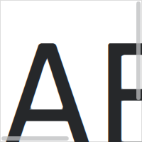

The first example demonstrates the simplest usage of ScrollView.

```
ScrollView {
    width: 200
    height: 200
    clip: true

    Label {
        text: "ABC"
        font.pixelSize: 224
    }
}
```

**Note:** ScrollView does not automatically clip its contents. If it is not used as a full-screen item, you should consider setting the clip property to `true`, as shown above.

The second example illustrates using an existing Flickable, that is, a ListView.

```
ScrollView {
    width: 200
    height: 200

    ListView {
        model: 20
        delegate: ItemDelegate {
            text: "Item " + index
        }
    }
}
```

### Sizing

As with Flickable, there are several things to keep in mind when using ScrollView:

- If only a single item is used within a ScrollView, the content size is automatically calculated based on the implicit size of its contained item. However, if more than one item is used (or an implicit size is not provided), the contentWidth and contentHeight properties must be set to the combined size of its contained items.
- If the content size is less than or equal to the size of the ScrollView, it will not be flickable.

### Scroll Bars

The horizontal and vertical scroll bars can be accessed and customized using the ScrollBar.horizontal and ScrollBar.vertical attached properties. The following example adjusts the scroll bar policies so that the horizontal scroll bar is always off, and the vertical scroll bar is always on.

```
ScrollView {
    // ...
    ScrollBar.horizontal.policy: ScrollBar.AlwaysOff
    ScrollBar.vertical.policy: ScrollBar.AlwaysOn
}
```

### Touch vs. Mouse Interaction

On touch, ScrollView enables flicking and makes the scroll bars non-interactive.

[video not shown]

When interacted with a mouse device, flicking is disabled and the scroll bars are interactive.

[video not shown]

Scroll bars can be made interactive on touch, or non-interactive when interacted with a mouse device, by setting the interactive property explicitly to `true` or `false`, respectively.

```
ScrollView {
    // ...
    ScrollBar.horizontal.interactive: true
    ScrollBar.vertical.interactive: true
}
```

**See also** ScrollBar, ScrollIndicator, Customizing ScrollView, Container Controls, and Focus Management in Qt Quick Controls.

## Property Documentation

contentChildren : list<Item>

This property holds the list of content children.

The list contains all items that have been declared in QML as children of the view.

**Note:** Unlike `contentData`, `contentChildren` does not include non-visual QML objects.

**See also** Item::children and contentData.

[default] contentData : list<Object>

This property holds the list of content data.

The list contains all objects that have been declared in QML as children of the view.

**Note:** Unlike `contentChildren`, `contentData` does include non-visual QML objects.

**See also** Item::data and contentChildren.

© The Qt Company Ltd  
Licensed under the GNU Free Documentation License, Version 1.3.  
https://doc.qt.io/qt-5.15/qml-qtquick-controls2-scrollview.html